# ecob2000_leture1

Joyce, Yameili, Tamires

9/13/2020

# Part1.CODES REPRODUCTION

```r
x <- 1:50
x <- 1:50
w <- 1 + sqrt(x)/2
example1 <- data.frame(x=x, y= x + rnorm(x)*w)
attach(example1)
```

Variables X &Y are created

```r
fm <- lm(y ~ x)
summary(fm)
```

```
##
## Call:
## lm(formula = y ~ x)
##
## Residuals:
##     Min      1Q  Median      3Q     Max
## -9.2914 -2.4942  0.3117  2.3208  6.2038
##
## Coefficients:
##             Estimate Std. Error t value Pr(>|t|)
## (Intercept) -1.25815    1.03345  -1.217    0.229
## x            1.08099    0.03527  30.648   <2e-16 ***
## ---
## Signif. codes:  0 '***' 0.001 '**' 0.01 '*' 0.05 '.' 0.1 ' ' 1
##
## Residual standard error: 3.599 on 48 degrees of freedom
## Multiple R-squared:  0.9514, Adjusted R-squared:  0.9504
## F-statistic: 939.3 on 1 and 48 DF,  p-value: < 2.2e-16
```

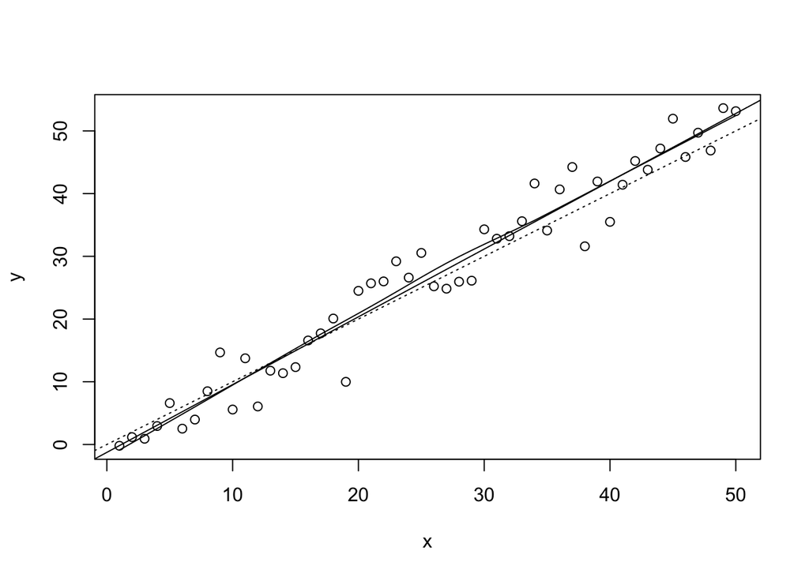

```r
lrf <- lowess(x, y)
plot(x, y)
lines(x, lrf$y)
abline(0, 1, lty=3)
abline(coef(fm))
```

#Data Explore: **PUMS** (Census Bureau’s "Public Use Microdata Survey)

```r
load("/Users/new/Desktop/acs2017_ny/acs2017_ny_data.RData")
#glimpse(acs2017_ny) try this later
acs2017_ny[1:10,1:7]
```

```
##    AGE female educ_nohs educ_hs educ_somecoll educ_college educ_advdeg
## 1   72      1         0       0             0            0           1
## 2   72      0         0       0             0            0           1
## 3   31      0         0       0             0            1           0
## 4   28      1         0       0             0            1           0
## 5   54      0         0       0             0            0           1
## 6   45      1         0       1             0            0           0
## 7   84      1         0       0             1            0           0
## 8   71      0         0       0             0            1           0
## 9   68      1         0       0             1            0           0
## 10  37      1         1       0             0            0           0
```

```r
attach(acs2017_ny)
summary(acs2017_ny)
```

```
##       AGE            female         educ_nohs        educ_hs
##  Min.   : 0.00   Min.   :0.0000   Min.   :0.000   Min.   :0.0000
##  1st Qu.:22.00   1st Qu.:0.0000   1st Qu.:0.000   1st Qu.:0.0000
##  Median :42.00   Median :1.0000   Median :0.000   Median :0.0000
##  Mean   :41.57   Mean   :0.5156   Mean   :0.271   Mean   :0.2804
##  3rd Qu.:60.00   3rd Qu.:1.0000   3rd Qu.:1.000   3rd Qu.:1.0000
##  Max.   :95.00   Max.   :1.0000   Max.   :1.000   Max.   :1.0000
##
##  educ_somecoll    educ_college     educ_advdeg                  SCHOOL
##  Min.   :0.000   Min.   :0.0000   Min.   :0.000   N/A              :  5569
##  1st Qu.:0.000   1st Qu.:0.0000   1st Qu.:0.000   No, not in school:144968
##  Median :0.000   Median :0.0000   Median :0.000   Yes, in school   : 46048
##  Mean   :0.173   Mean   :0.1567   Mean   :0.119   Missing          :     0
##  3rd Qu.:0.000   3rd Qu.:0.0000   3rd Qu.:0.000
##  Max.   :1.000   Max.   :1.0000   Max.   :1.000
##
##                         EDUC
##  Grade 12                 :55119
##  4 years of college       :30802
##  5+ years of college      :23385
##  1 year of college        :19947
##  Nursery school to grade 4:14240
##  2 years of college       :14065
##  (Other)                  :39027
##                                           EDUCD
##  Regular high school diploma                 :35689
##  Bachelor's degree                           :30802
##  1 or more years of college credit, no degree:19947
##  Master's degree                             :17010
##  Associate's degree, type not specified      :14065
##  Some college, but less than 1 year          : 9086
##  (Other)                                     :69986
##                                      DEGFIELD
##  N/A                                     :142398
##  Business                                :  9802
##  Education Administration and Teaching   :  6708
##  Social Sciences                         :  4836
##  Medical and Health Sciences and Services:  3919
##  Fine Arts                               :  3491
##  (Other)                                 : 25431
```

[output cut: 209 more lines]

```
##  Min.   :0.00000   Min.   :0.00000   Min.   :0.000     Min.   :0.0000
##  1st Qu.:0.00000   1st Qu.:0.00000   1st Qu.:0.000     1st Qu.:0.0000
##  Median :0.00000   Median :0.00000   Median :0.000     Median :0.0000
##  Mean   :0.01332   Mean   :0.05506   Mean   :0.122     Mean   :0.1965
##  3rd Qu.:0.00000   3rd Qu.:0.00000   3rd Qu.:0.000     3rd Qu.:0.0000
##  Max.   :1.00000   Max.   :1.00000   Max.   :1.000     Max.   :1.0000
##
##  below_200poverty   foodstamps
##  Min.   :0.0000   Min.   :0.0000
##  1st Qu.:0.0000   1st Qu.:0.0000
##  Median :0.0000   Median :0.0000
##  Mean   :0.2676   Mean   :0.1465
##  3rd Qu.:1.0000   3rd Qu.:0.0000
##  Max.   :1.0000   Max.   :1.0000
##
```

```r
print(NN_obs <- length(AGE))
```

```
## [1] 196585
```

the total population in the data.

## Average Age of Men&Women

```r
summary(AGE[female == 1])
```

```
##    Min. 1st Qu.  Median    Mean 3rd Qu.    Max.
##    0.00   23.00   44.00   42.72   61.00   95.00
```

```r
summary(AGE[!female])
```

```
##    Min. 1st Qu.  Median    Mean 3rd Qu.    Max.
##    0.00   21.00   40.00   40.35   59.00   95.00
```

note: female=1 (i.e. women) and those not female=1 (so logical not, denoted with the “!” symbol, i.e. men)

## Mean&Standard Deviation Function

```r
mean(AGE[female == 1])
```

```
## [1] 42.71629
```

```r
sd(AGE[female == 1])
```

```
## [1] 23.72012
```

```r
mean(AGE[!female])
```

```
## [1] 40.35398
```

```r
sd(AGE[!female])
```

```
## [1] 23.1098
```

## Educational Attainments in NYC

Q4. Tell me something else interesting, that you learned from the data, for example about educational attainments In different neighborhoods in the city. Are there surprises for you?

In New York city,the majority of people in NYC receive at least high school education among which people with regular high school diploma and Bachelor Degree holer rank the first top2 with 35689 and 30802 respectively.Only small portion quit school before primary education or even receive no education.

```r
summary(EDUCD)
```

```
##                            N/A or no schooling
##                                              0
##                                            N/A
##                                           5569
##                         No schooling completed
##                                           6310
##                      Nursery school to grade 4
##                                              0
##                      Nursery school, preschool
##                                           2760
##                                   Kindergarten
##                                           2247
##                            Grade 1, 2, 3, or 4
##                                              0
##                                        Grade 1
##                                           2131
##                                        Grade 2
##                                           2276
##                                        Grade 3
##                                           2418
##                                        Grade 4
##                                           2408
##                            Grade 5, 6, 7, or 8
##                                              0
##                                   Grade 5 or 6
##                                              0
##                                        Grade 5
##                                           2835
##                                        Grade 6
##                                           3365
##                                   Grade 7 or 8
##                                              0
##                                        Grade 7
##                                           2839
##                                        Grade 8
##                                           4040
##                                        Grade 9
##                                           4088
##                                       Grade 10
##                                           4644
```

[output cut: 33 more lines]

```
##                                              0
##           6 years of college (6+ in 1960-1970)
##                                              0
##                             7 years of college
##                                              0
##                            8+ years of college
##                                              0
##                                Master's degree
##                                          17010
## Professional degree beyond a bachelor's degree
##                                           4051
##                                Doctoral degree
##                                           2324
##                                        Missing
##                                              0
```

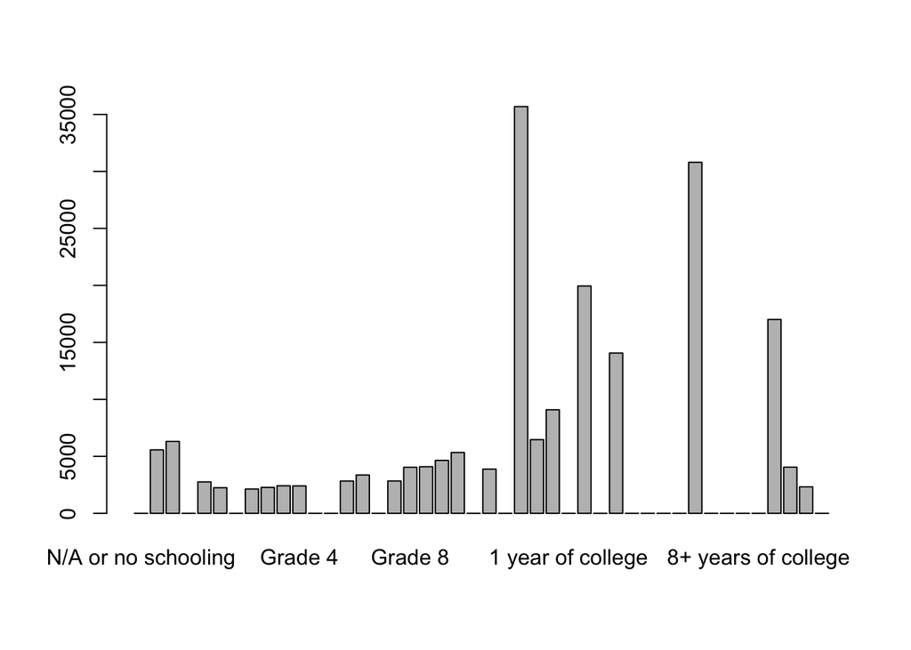

```r
plot(EDUCD)
```

```r
summary(DEGFIELD)
```

```
##                                                        N/A
##                                                     142398
##                                                Agriculture
##                                                        262
##                          Environment and Natural Resources
##                                                        282
##                                               Architecture
##                                                        442
##                     Area, Ethnic, and Civilization Studies
##                                                        258
##                                             Communications
##                                                       2105
##                                 Communication Technologies
##                                                         79
##                          Computer and Information Sciences
##                                                       1530
##                     Cosmetology Services and Culinary Arts
##                                                         50
##                      Education Administration and Teaching
##                                                       6708
##                                                Engineering
##                                                       3145
##                                   Engineering Technologies
##                                                        246
##                          Linguistics and Foreign Languages
##                                                        683
##                               Family and Consumer Sciences
##                                                        272
##                                                        Law
##                                                        124
##              English Language, Literature, and Composition
##                                                       2315
##                                Liberal Arts and Humanities
##                                                        779
##                                            Library Science
##                                                         42
##                                  Biology and Life Sciences
##                                                       2361
##                                 Mathematics and Statistics
##                                                        904
```

[output cut: 23 more lines]

```
##                                                         46
##           Electrical and Mechanic Repairs and Technologies
##                                                         14
##                   Precision Production and Industrial Arts
##                                                          0
##                   Transportation Sciences and Technologies
##                                                         84
##                                                  Fine Arts
##                                                       3491
##                   Medical and Health Sciences and Services
##                                                       3919
##                                                   Business
##                                                       9802
##                                                    History
##                                                       1511
```

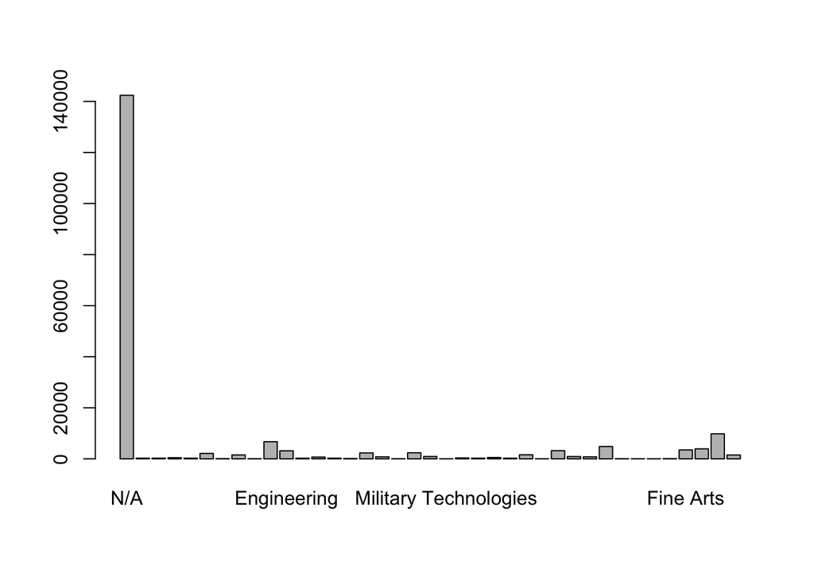

```r
plot(DEGFIELD)
```

# Q4. Dice experiments

Before class, you should have done about 20 experiments where you roll the dice (or use the app) and record whether the result was a 6 or not. If you’ve got an app, then drawing integers from interval [1,6] is like fair dice; integers from [1,5] will be rather boring and never produce a 6; but integers from [1,8] or [1,10] will produce 6 but at a lower rate than fair dice.

## Rolling the dice physically

*[1] p(6)=0*

## 1.Fair Dice

```r
roll_dice=function(n) sample(1:6,n,rep=T)
roll_dice(20)
```

```
##  [1] 6 4 1 4 2 4 1 2 3 5 6 4 4 2 1 5 1 4 5 3
```

```r
mean(roll_dice(20))
```

```
## [1] 4.15
```

```r
sd(roll_dice(20))
```

```
## [1] 1.65434
```

```r
roll_dice(40)
```

```
##  [1] 3 2 3 6 1 3 1 5 1 1 3 4 2 5 2 1 6 1 3 6 3 5 4 5 3 6 2 2 4 2 5 3 3 5 3 1 2 5
## [39] 5 4
```

```r
mean(roll_dice(40))
```

```
## [1] 3.5
```

```r
sd(roll_dice(40))
```

```
## [1] 1.648426
```

[output not shown]

# Q5. S&P500

Differences in means can be complicated. Find the mean return on SP500 index (choose a time period). What is the mean return on days when the previous day’s return was positive? When the previous 2 days were positive? Negative? Now read about “hot hands fallacy” and tell if you think that helps investment strategy. (You might start with this tweet, and read the papers referenced.)

## Data Source:Yahoo Finance

[output not shown]

[output not shown]

[output not shown]